# Laboratorio 1: Analizando Variables Climáticas con Datos CRU

Laboratorio — R para Economistas

Araceli Martínez

21 de March de 2026

# 1 Introducción

En esta práctica aprenderemos a descargar, limpiar y visualizar datos climáticos históricos utilizando el conjunto de datos **CRU TS 4.09** (Climatic Research Unit gridded Time Series), que cubre el período **1901–2024** con resolución mensual para más de 190 países.

Trabajaremos con cuatro variables principales:

| Código | Variable | Unidad |
| --- | --- | --- |
| `pre` | Precipitación | mm |
| `tmp` | Temperatura media | °C |
| `tmn` | Temperatura mínima | °C |
| `tmx` | Temperatura máxima | °C |

> **Fuente de los datos:** University of East Anglia, Climatic Research Unit.  
> URL base: `https://crudata.uea.ac.uk/cru/data/hrg/cru_ts_4.09/`

# 2 Configuración del Entorno

## 2.1 Librerías necesarias

```r
# Instalar si no está disponible:
# install.packages("readr")

library(readr)
```

## 2.2 Directorio de trabajo

```r
setwd("~/Documents/Cursos-R/Tarea-0")
```

# 3 Descarga de Datos

## 3.1 Definir variables y países

Seleccionamos las cuatro variables climáticas y un conjunto amplio de países del G20 más la Unión Europea.

```r
variables <- c("pre", "tmn", "tmp", "tmx")

g20_countries <- unique(c(
  "Argentina", "Australia", "Brazil", "Canada", "China",
  "France", "Germany", "India", "Indonesia", "Italy",
  "Japan", "Mexico", "Russia", "Saudi_Arabia", "South_Africa",
  "South_Korea", "Turkey", "United_Kingdom", "USA",
  "Austria", "Belgium", "Bulgaria", "Croatia", "Cyprus",
  "Czech_Republic", "Denmark", "Estonia", "Finland", "Greece",
  "Hungary", "Ireland", "Latvia", "Lithuania", "Luxembourg",
  "Malta", "Netherlands", "Poland", "Portugal", "Romania",
  "Slovakia", "Slovenia", "Spain", "Sweden"
))

cat("Total de países:", length(g20_countries), "\n")
```

```
## Total de países: 43
```

```r
cat("Variables:", paste(variables, collapse = ", "), "\n")
```

```
## Variables: pre, tmn, tmp, tmx
```

## 3.2 Descargar archivos `.per`

El loop descarga cada archivo solo si **no existe ya** en el directorio de trabajo, por lo que es seguro volver a correr el bloque sin re-descargar todo. Los errores 404 se capturan e imprimen sin detener la ejecución.

> ⚠️ **Antes de hacer Knit:** asegúrate de que tu directorio de trabajo es correcto (`setwd`) y que tienes conexión a internet. La descarga completa puede tardar varios minutos.

```r
base_url <- "https://crudata.uea.ac.uk/cru/data/hrg/cru_ts_4.09/crucy.2503061057.v4.09/countries"

total    <- length(g20_countries) * length(variables)
contador <- 0

for (country in g20_countries) {
  for (var in variables) {
    contador <- contador + 1
    file     <- paste0("crucy.v4.09.1901.2024.", country, ".", var, ".per")

    if (!file.exists(file)) {
      tryCatch(
        {
          download.file(
            url      = paste0(base_url, "/", var, "/", file),
            destfile = file,
            mode     = "wb",
            quiet    = TRUE
          )
          message(sprintf("[%d/%d] Descargado: %s", contador, total, file))
        },
        error = function(e) message(sprintf("[%d/%d] 404 – no encontrado: %s", contador, total, file))
      )
    } else {
      message(sprintf("[%d/%d] Ya existe, omitido: %s", contador, total, file))
    }
  }
}

message("✔ Descarga completada.")
```

# 4 Carga de Datos

## 4.1 Estructura de los archivos `.per`

Cada archivo `.per` tiene 18 columnas: año, doce meses, cuatro estaciones (MAM, JJA, SON, DJF) y el valor anual (ANN). Las primeras 4 líneas son encabezado y se omiten con `skip = 4`.

```r
col_names <- c("Year", "Jan", "Feb", "Mar", "Apr", "May", "Jun",
               "Jul", "Aug", "Sep", "Oct", "Nov", "Dec",
               "MAM", "JJA", "SON", "DJF", "ANN")
```

> **Nota sobre estaciones:** - **DJF** (Dec–Feb): Invierno  
> - **MAM** (Mar–May): Primavera  
> - **JJA** (Jun–Ago): Verano  
> - **SON** (Sep–Nov): Otoño

## 4.2 Leer archivos y construir la lista de datos

Cada archivo `.per` se lee con `read_table()`, saltando las 4 primeras líneas de encabezado. El valor `-999.0` indica dato faltante y se convierte automáticamente a `NA`. El resultado es una lista nombrada con la clave `"Pais_variable"` (ej. `"Mexico_tmp"`).

```r
climate_data   <- list()
no_encontrados <- c()

for (country in g20_countries) {
  for (var in variables) {
    file <- paste0("crucy.v4.09.1901.2024.", country, ".", var, ".per")
    if (file.exists(file)) {
      df <- read_table(file, skip = 4, col_names = col_names,
                       na = "-999.0", show_col_types = FALSE)
      df$Country  <- country
      df$Variable <- var
      climate_data[[paste0(country, "_", var)]] <- df
    } else {
      no_encontrados <- c(no_encontrados, file)
    }
  }
}

cat(sprintf("Entradas cargadas en climate_data: %d de %d esperadas\n",
            length(climate_data),
            length(g20_countries) * length(variables)))
```

```
## Entradas cargadas en climate_data: 172 de 172 esperadas
```

```r
if (length(no_encontrados) > 0) {
  cat(sprintf("Archivos no encontrados (%d):\n", length(no_encontrados)))
  cat(paste(" -", no_encontrados, collapse = "\n"), "\n")
}

# Vista rapida de la estructura de un dataframe de ejemplo
cat("\nEstructura de Mexico_tmp:\n")
```

```
##
## Estructura de Mexico_tmp:
```

```r
str(climate_data[["Mexico_tmp"]])
```

```
## spc_tbl_ [124 × 20] (S3: spec_tbl_df/tbl_df/tbl/data.frame)
##  $ Year    : num [1:124] 1901 1902 1903 1904 1905 ...
##  $ Jan     : num [1:124] 16.1 15.3 15.5 14.6 15.4 15.1 17.1 16.1 16.9 15.5 ...
##  $ Feb     : num [1:124] 16.3 16.1 15.3 17.5 14.7 16.3 17.7 16.4 16.7 15.4 ...
##  $ Mar     : num [1:124] 18.6 18.4 18.1 20.1 19 18 20.2 20 18.9 19.5 ...
##  $ Apr     : num [1:124] 20.5 22.1 21 21.6 20.8 21.1 21.2 21.8 21.1 21.1 ...
##  $ May     : num [1:124] 23.2 24.1 22.7 23.1 23.6 23.3 22.3 23.3 23.2 23.5 ...
##  $ Jun     : num [1:124] 24.7 25.6 24 24.6 24.9 25.4 24.5 25.1 25.1 24.8 ...
##  $ Jul     : num [1:124] 25.2 24.8 24.8 24.5 24.6 24.8 24.8 24.7 25.1 25 ...
##  $ Aug     : num [1:124] 25.2 25 24.6 24.5 25.4 24.2 24.8 24.7 24.6 25.1 ...
##  $ Sep     : num [1:124] 23.9 24 23.4 23.8 24.3 24 24.2 23.5 23.3 24.2 ...
##  $ Oct     : num [1:124] 21.9 21.7 20.8 21.2 21.4 20.7 21.7 20.4 21.2 21 ...
##  $ Nov     : num [1:124] 18.9 18.9 18.2 17.9 18.6 17.8 17.2 17.9 19.2 18.4 ...
##  $ Dec     : num [1:124] 15.7 16 15.5 15.9 14.2 16.8 16.4 16.1 14 16.1 ...
##  $ MAM     : num [1:124] 20.8 21.6 20.6 21.6 21.1 20.8 21.3 21.7 21.1 21.4 ...
##  $ JJA     : num [1:124] 25 25.1 24.5 24.5 25 24.8 24.7 24.8 24.9 25 ...
##  $ SON     : num [1:124] 21.6 21.5 20.8 21 21.4 20.8 21 20.6 21.3 21.2 ...
##  $ DJF     : num [1:124] 15.7 15.6 15.9 15.3 15.2 17.2 16.3 16.6 14.9 16.8 ...
##  $ ANN     : num [1:124] 20.9 21 20.3 20.8 20.6 20.6 21 20.8 20.8 20.8 ...
##  $ Country : chr [1:124] "Mexico" "Mexico" "Mexico" "Mexico" ...
##  $ Variable: chr [1:124] "tmp" "tmp" "tmp" "tmp" ...
##  - attr(*, "spec")=
##   .. cols(
##   ..   Year = col_double(),
##   ..   Jan = col_double(),
##   ..   Feb = col_double(),
##   ..   Mar = col_double(),
##   ..   Apr = col_double(),
##   ..   May = col_double(),
##   ..   Jun = col_double(),
##   ..   Jul = col_double(),
##   ..   Aug = col_double(),
##   ..   Sep = col_double(),
##   ..   Oct = col_double(),
##   ..   Nov = col_double(),
##   ..   Dec = col_double(),
##   ..   MAM = col_double(),
##   ..   JJA = col_double(),
##   ..   SON = col_double(),
##   ..   DJF = col_double(),
##   ..   ANN = col_double()
##   .. )
```

# 5 Sección 1: Precipitación Mensual Promedio para México

## 5.1 Estadísticas descriptivas

```r
mexico_pre <- climate_data[["Mexico_pre"]]

months <- c("Jan", "Feb", "Mar", "Apr", "May", "Jun",
            "Jul", "Aug", "Sep", "Oct", "Nov", "Dec")

mean_monthly <- as.integer(round(sapply(months, function(m) mean(mexico_pre[[m]], na.rm = TRUE))))
sd_monthly   <- as.integer(round(sapply(months, function(m) sd(mexico_pre[[m]], na.rm = TRUE))))
min_monthly  <- as.integer(round(sapply(months, function(m) min(mexico_pre[[m]], na.rm = TRUE))))
max_monthly  <- as.integer(round(sapply(months, function(m) max(mexico_pre[[m]], na.rm = TRUE))))

stats_mexico <- data.frame(
  Mes    = months,
  Media  = mean_monthly,
  DE     = sd_monthly,
  Mínimo = min_monthly,
  Máximo = max_monthly
)

knitr::kable(stats_mexico,
             caption = "Estadísticas de precipitación mensual para México (1901–2024)",
             align   = "lrrrr")
```

Estadísticas de precipitación mensual para México (1901–2024)

| Mes | Media | DE | Mínimo | Máximo |
| --- | --- | --- | --- | --- |
| Jan | 22 | 9 | 3 | 52 |
| Feb | 16 | 7 | 5 | 40 |
| Mar | 14 | 6 | 4 | 42 |
| Apr | 17 | 7 | 5 | 40 |
| May | 41 | 13 | 15 | 80 |
| Jun | 100 | 21 | 57 | 149 |
| Jul | 124 | 24 | 70 | 217 |
| Aug | 125 | 24 | 79 | 192 |
| Sep | 139 | 27 | 76 | 218 |
| Oct | 79 | 24 | 18 | 135 |
| Nov | 30 | 13 | 7 | 66 |
| Dec | 26 | 12 | 5 | 66 |

## 5.2 Gráfico de barras

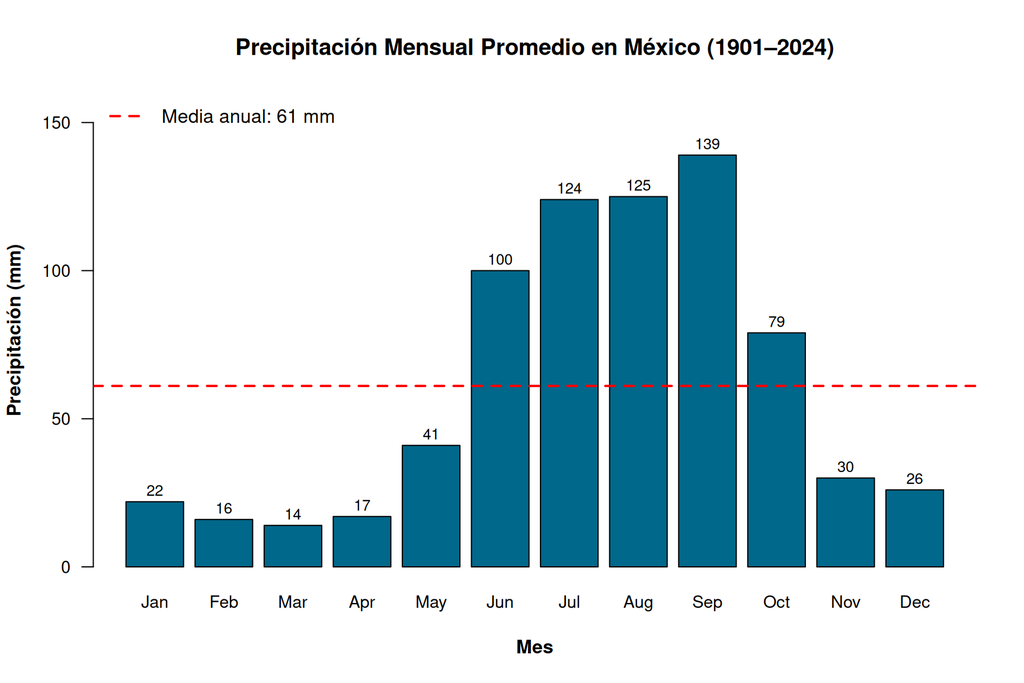

Precipitación mensual promedio en México (1901–2024)

```r
bp_mexico <- barplot(
  mean_monthly,
  names.arg = months,
  col       = "deepskyblue4",
  main      = "Precipitación Mensual Promedio en México (1901–2024)",
  ylab      = "Precipitación (mm)",
  xlab      = "Mes",
  ylim      = c(0, max(mean_monthly) * 1.15),
  cex.names = 0.9,
  cex.axis  = 0.9,
  las       = 1,
  font.lab  = 2
)

text(x      = bp_mexico[, 1],
     y      = mean_monthly + 2,
     labels = mean_monthly,
     cex    = 0.8,
     col    = "black",
     adj    = c(0.5, 0))

abline(h   = mean(mean_monthly),
       col = "red", lwd = 2, lty = 2)

legend("topleft",
       legend = paste("Media anual:", round(mean(mean_monthly)), "mm"),
       col    = "red", lty = 2, lwd = 2, bty = "n")
```

**Interpretación:** La precipitación en México es claramente estacional, con un pico marcado en los meses de verano (junio–septiembre) asociado a la temporada de lluvias. Los meses de invierno presentan valores muy bajos.

# 6 Sección 2: Precipitación Anual Promedio por País (G20)

## 6.1 Calcular medias anuales

```r
annual_pre <- data.frame(Country = character(), Mean_ANN = numeric())

for (country in g20_countries) {
  key <- paste0(country, "_pre")
  if (key %in% names(climate_data)) {
    mean_ann   <- mean(climate_data[[key]]$ANN, na.rm = TRUE)
    annual_pre <- rbind(annual_pre,
                        data.frame(Country = country, Mean_ANN = mean_ann))
  }
}

# Ordenar de mayor a menor
annual_pre <- annual_pre[order(annual_pre$Mean_ANN, decreasing = TRUE), ]

knitr::kable(head(annual_pre, 10),
             caption = "Top 10 países con mayor precipitación anual promedio",
             digits  = 1,
             col.names = c("País", "Precipitación media anual (mm)"))
```

Top 10 países con mayor precipitación anual promedio

|  | País | Precipitación media anual (mm) |
| --- | --- | --- |
| 9 | Indonesia | 2644.7 |
| 3 | Brazil | 1774.1 |
| 11 | Japan | 1698.8 |
| 16 | South_Korea | 1338.2 |
| 41 | Slovenia | 1236.2 |
| 18 | United_Kingdom | 1176.9 |
| 31 | Ireland | 1163.2 |
| 23 | Croatia | 1149.2 |
| 8 | India | 1129.0 |
| 20 | Austria | 1086.9 |

## 6.2 Gráfico comparativo

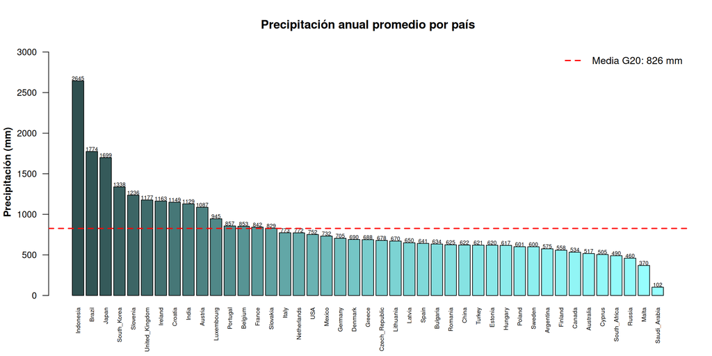

Precipitación anual promedio — países G20 y UE

```r
blues_palette <- colorRampPalette(c("#97FFFF", "#8DEEEE", "#79CDCD", "#528B8B", "#2F4F4F"))
colors        <- blues_palette(nrow(annual_pre))[rank(annual_pre$Mean_ANN)]

bp_g20 <- barplot(
  annual_pre$Mean_ANN,
  names.arg = annual_pre$Country,
  las       = 2,
  col       = colors,
  main      = "Precipitación anual promedio por país",
  ylab      = "Precipitación (mm)",
  ylim      = c(0, max(annual_pre$Mean_ANN) * 1.15),
  cex.names = 0.6,
  cex.axis  = 0.9,
  font.lab  = 2
)

text(x      = bp_g20[, 1],
     y      = annual_pre$Mean_ANN + 5,
     labels = round(annual_pre$Mean_ANN),
     cex    = 0.55,
     col    = "black",
     adj    = c(0.5, 0))

abline(h   = mean(annual_pre$Mean_ANN),
       col = "red", lwd = 2, lty = 2)

legend("topright",
       legend = paste("Media G20:", round(mean(annual_pre$Mean_ANN)), "mm"),
       col    = "red", lty = 2, lwd = 2, bty = "n")
```

# 7 Sección 3: Temperatura Anual Promedio por País (G20)

## 7.1 Calcular medias anuales de temperatura

```r
annual_tmp <- data.frame(Country = character(), Mean_ANN = numeric())

for (country in g20_countries) {
  key <- paste0(country, "_tmp")
  if (key %in% names(climate_data)) {
    mean_ann   <- mean(climate_data[[key]]$ANN, na.rm = TRUE)
    annual_tmp <- rbind(annual_tmp,
                        data.frame(Country = country, Mean_ANN = mean_ann))
  }
}

annual_tmp <- annual_tmp[order(annual_tmp$Mean_ANN, decreasing = TRUE), ]

knitr::kable(head(annual_tmp, 10),
             caption = "Top 10 países más cálidos (temperatura anual promedio)",
             digits  = 1,
             col.names = c("País", "Temperatura media anual (°C)"))
```

Top 10 países más cálidos (temperatura anual promedio)

|  | País | Temperatura media anual (°C) |
| --- | --- | --- |
| 9 | Indonesia | 25.9 |
| 14 | Saudi_Arabia | 25.2 |
| 3 | Brazil | 24.9 |
| 8 | India | 23.7 |
| 2 | Australia | 21.6 |
| 12 | Mexico | 21.2 |
| 35 | Malta | 19.5 |
| 24 | Cyprus | 18.2 |
| 15 | South_Africa | 17.8 |
| 38 | Portugal | 15.4 |

## 7.2 Gráfico comparativo

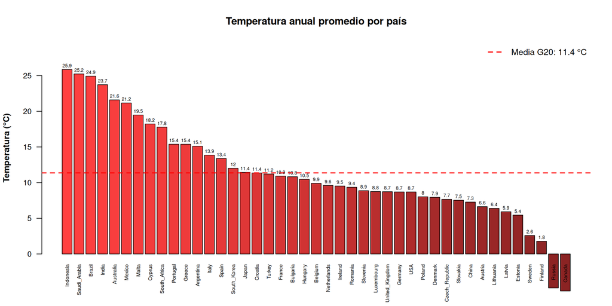

Temperatura anual promedio — países G20 y UE

```r
dark_palette <- colorRampPalette(c("brown4", "brown", "brown3", "brown2", "brown1"))
colors       <- dark_palette(nrow(annual_tmp))[rank(annual_tmp$Mean_ANN)]

bp_tmp_g20 <- barplot(
  annual_tmp$Mean_ANN,
  names.arg = annual_tmp$Country,
  las       = 2,
  col       = colors,
  main      = "Temperatura anual promedio por país",
  ylab      = "Temperatura (°C)",
  ylim      = c(0, max(annual_tmp$Mean_ANN) * 1.15),
  cex.names = 0.6,
  cex.axis  = 0.9,
  font.lab  = 2
)

text(x      = bp_tmp_g20[, 1],
     y      = annual_tmp$Mean_ANN + 0.3,
     labels = round(annual_tmp$Mean_ANN, 1),
     cex    = 0.55,
     col    = "black",
     adj    = c(0.5, 0))

abline(h   = mean(annual_tmp$Mean_ANN),
       col = "red", lwd = 2, lty = 2)

legend("topright",
       legend = paste("Media G20:", round(mean(annual_tmp$Mean_ANN), 1), "°C"),
       col    = "red", lty = 2, lwd = 2, bty = "n")
```

# 8 Sección 4: Series de Tiempo con Tendencia

La temperatura promedio anual de un país puede analizarse como una **serie de tiempo**. Ajustar una regresión lineal (`lm`) nos permite visualizar la tendencia a largo plazo.

## 8.1 México — Temperatura

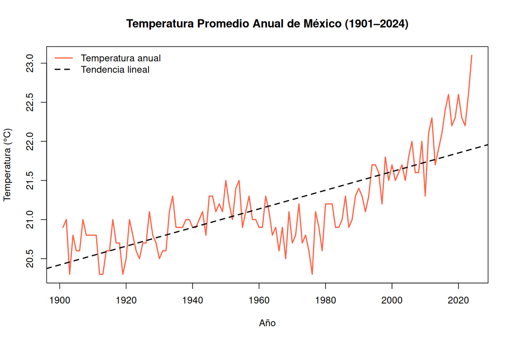

Serie de tiempo de temperatura anual en México con tendencia lineal

```r
country_ts <- climate_data[["Mexico_tmp"]]
trend      <- lm(ANN ~ Year, data = country_ts)

plot(country_ts$Year, country_ts$ANN,
     type = "l", col = "tomato", lwd = 2,
     main = "Temperatura Promedio Anual de México (1901–2024)",
     xlab = "Año", ylab = "Temperatura (°C)")

abline(trend, col = "black", lwd = 2, lty = 2)

legend("topleft",
       legend = c("Temperatura anual", "Tendencia lineal"),
       col    = c("tomato", "black"),
       lty    = c(1, 2), lwd = 2, bty = "n")
```

```r
cat(sprintf("Pendiente estimada: %.4f °C/año\n", coef(trend)["Year"]))
```

```
## Pendiente estimada: 0.0119 °C/año
```

```r
cat(sprintf("Calentamiento total estimado (1901-2024): %.2f °C\n",
            coef(trend)["Year"] * (2024 - 1901)))
```

```
## Calentamiento total estimado (1901-2024): 1.47 °C
```

> **Interpretación económica:** El calentamiento observado tiene implicaciones para la productividad agrícola, el consumo energético y los patrones de migración, temas centrales en la economía del desarrollo y la economía ambiental.

## 8.2 México — Precipitación

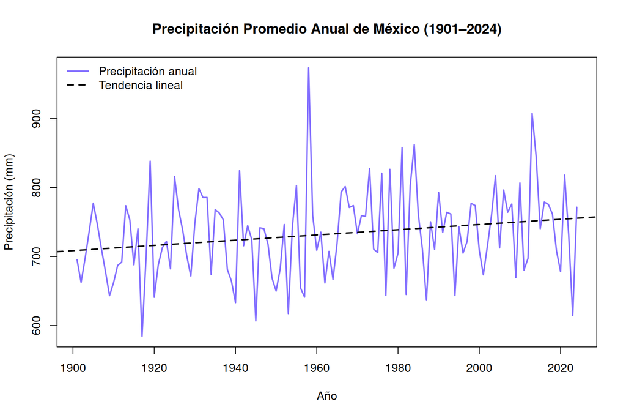

Serie de tiempo de precipitación anual en México con tendencia lineal

```r
country_ts <- climate_data[["Mexico_pre"]]
trend      <- lm(ANN ~ Year, data = country_ts)

plot(country_ts$Year, country_ts$ANN,
     type = "l", col = "slateblue1", lwd = 2,
     main = "Precipitación Promedio Anual de México (1901–2024)",
     xlab = "Año", ylab = "Precipitación (mm)")

abline(trend, col = "black", lwd = 2, lty = 2)

legend("topleft",
       legend = c("Precipitación anual", "Tendencia lineal"),
       col    = c("slateblue1", "black"),
       lty    = c(1, 2), lwd = 2, bty = "n")
```

# 9 Sección 5: Tasa de Crecimiento Anual (YoY)

La **tasa de crecimiento año a año** (Year-over-Year, YoY) mide el cambio porcentual entre años consecutivos:

$$\text{YoY}_t = \frac{X_t -
X_{t-1}}{X_{t-1}} \times 100$$

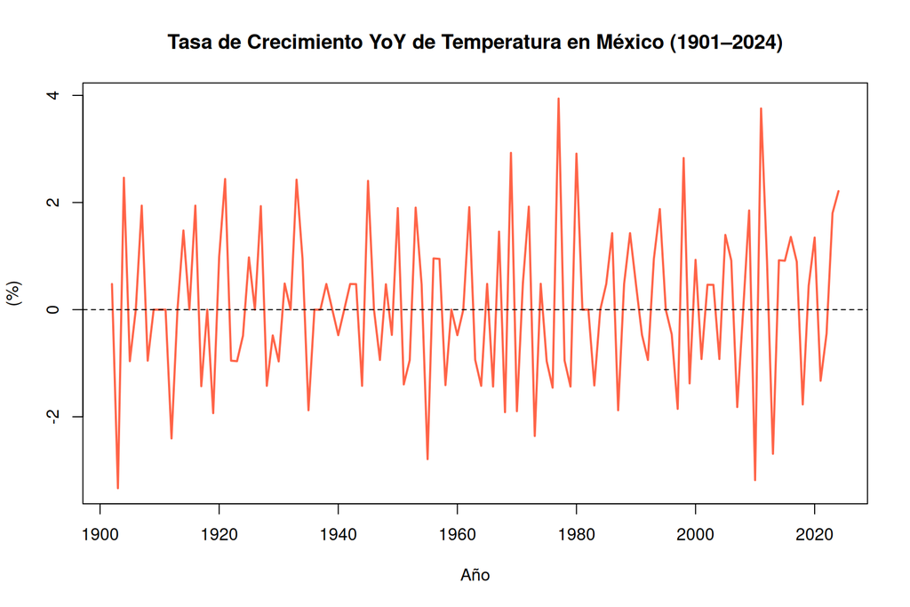

Tasa de crecimiento YoY de la temperatura anual en México

```r
country_ts <- climate_data[["Mexico_tmp"]]
country_ts$YoY_growth <- c(NA, diff(country_ts$ANN) / head(country_ts$ANN, -1) * 100)

plot(country_ts$Year[-1], country_ts$YoY_growth[-1],
     type = "l", col = "tomato", lwd = 2,
     main = "Tasa de Crecimiento YoY de Temperatura en México (1901–2024)",
     xlab = "Año", ylab = "(%)")

abline(h = 0, col = "black", lty = 2)
```

## 9.1 México — Precipitación YoY

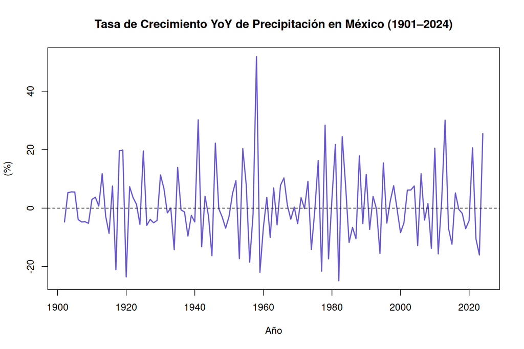

Tasa de crecimiento YoY de la precipitación anual en México

```r
country_ts <- climate_data[["Mexico_pre"]]
country_ts$YoY_growth <- c(NA, diff(country_ts$ANN) / head(country_ts$ANN, -1) * 100)

plot(country_ts$Year[-1], country_ts$YoY_growth[-1],
     type = "l", col = "slateblue", lwd = 2,
     main = "Tasa de Crecimiento YoY de Precipitación en México (1901–2024)",
     xlab = "Año", ylab = "(%)")

abline(h = 0, col = "black", lty = 2)
```

# 10 Sección 6: Bubble Plot — Años Extremos de Temperatura

## 10.1 Construir el data frame de años extremos

```r
extreme_years <- data.frame(
  Country   = character(),
  Hottest   = numeric(),
  Coldest   = numeric(),
  Year_Hot  = numeric(),
  Year_Cold = numeric()
)

for (country in g20_countries) {
  key <- paste0(country, "_tmp")
  if (key %in% names(climate_data)) {
    df <- climate_data[[key]]
    extreme_years <- rbind(extreme_years, data.frame(
      Country   = country,
      Hottest   = round(max(df$ANN, na.rm = TRUE), 2),
      Coldest   = round(min(df$ANN, na.rm = TRUE), 2),
      Year_Hot  = df$Year[which.max(df$ANN)],
      Year_Cold = df$Year[which.min(df$ANN)]
    ))
  }
}

knitr::kable(extreme_years,
             caption = "Anos extremos de temperatura por pais",
             digits  = 2,
             col.names = c("Pais", "Temp. maxima (C)", "Temp. minima (C)",
                           "Ano mas calido", "Ano mas frio"))
```

Anos extremos de temperatura por pais

| Pais | Temp. maxima (C) | Temp. minima (C) | Ano mas calido | Ano mas frio |
| --- | --- | --- | --- | --- |
| Argentina | 16.2 | 14.2 | 2023 | 1956 |
| Australia | 22.8 | 20.7 | 2019 | 1917 |
| Brazil | 26.0 | 24.3 | 2015 | 1917 |
| Canada | -3.0 | -7.2 | 2010 | 1972 |
| China | 8.8 | 6.5 | 2024 | 1956 |
| France | 13.2 | 9.5 | 2022 | 1963 |
| Germany | 11.2 | 6.8 | 2024 | 1940 |
| India | 24.8 | 22.8 | 2009 | 1917 |
| Indonesia | 26.5 | 25.5 | 2024 | 1956 |
| Italy | 16.0 | 12.5 | 2024 | 1940 |
| Japan | 13.6 | 10.0 | 2024 | 1913 |
| Mexico | 23.1 | 20.3 | 2024 | 1903 |
| Russia | -1.7 | -6.6 | 2020 | 1969 |
| Saudi_Arabia | 26.9 | 24.2 | 2010 | 1911 |
| South_Africa | 19.4 | 16.7 | 2019 | 1907 |
| South_Korea | 14.3 | 10.5 | 2024 | 1917 |
| Turkey | 13.3 | 9.8 | 2024 | 1911 |
| United_Kingdom | 10.1 | 7.7 | 2022 | 1919 |
| USA | 10.5 | 7.4 | 2016 | 1917 |
| Austria | 9.4 | 4.6 | 2024 | 1940 |
| Belgium | 12.0 | 8.1 | 2022 | 1963 |
| Bulgaria | 13.4 | 9.2 | 2024 | 1933 |
| Croatia | 14.2 | 9.3 | 2024 | 1940 |
| Cyprus | 20.2 | 16.7 | 2024 | 1903 |
| Czech_Republic | 10.6 | 5.4 | 2024 | 1940 |
| Denmark | 10.0 | 5.9 | 2020 | 1942 |
| Estonia | 8.2 | 2.8 | 2020 | 1941 |
| Finland | 4.4 | -0.9 | 2020 | 1902 |
| Greece | 17.6 | 14.1 | 2024 | 1933 |
| Hungary | 13.3 | 8.2 | 2024 | 1940 |
| Ireland | 10.8 | 8.5 | 2023 | 1963 |
| Latvia | 8.6 | 3.4 | 2020 | 1941 |
| Lithuania | 9.1 | 3.9 | 2024 | 1941 |
| Luxembourg | 11.0 | 7.0 | 2022 | 1963 |
| Malta | 21.3 | 18.4 | 2024 | 1906 |
| Netherlands | 11.7 | 7.8 | 2024 | 1963 |
| Poland | 10.9 | 5.7 | 2024 | 1940 |
| Portugal | 17.3 | 14.1 | 2022 | 1917 |
| Romania | 12.2 | 7.3 | 2024 | 1940 |
| Slovakia | 10.5 | 5.2 | 2024 | 1940 |
| Slovenia | 11.7 | 6.7 | 2024 | 1940 |
| Spain | 15.3 | 12.1 | 2022 | 1917 |
| Sweden | 4.8 | 0.4 | 2020 | 1902 |

## 10.2 Función `plot_bubble_panel`

La función dibuja un panel por cada año extremo. Cuando se llama desde un chunk de RMarkdown **sin** `png()`/`dev.off()`, el gráfico se renderiza directamente en el HTML.

```r
plot_bubble_panel <- function(data, temp_col, year_col, title, ramp, unit) {

  years      <- sort(unique(data[[year_col]]))
  chunks     <- split(years, ceiling(seq_along(years) / 6))
  global_min <- min(data[[temp_col]])
  global_max <- max(data[[temp_col]])

  for (i in seq_along(chunks)) {

    chunk_years <- chunks[[i]]
    n_panels    <- length(chunk_years)
    n_cols      <- 3
    n_rows      <- ceiling(n_panels / n_cols)

    par(mfrow = c(n_rows, n_cols),
        mar   = c(5.5, 4.5, 3.5, 1.5),
        oma   = c(2, 2.5, 4, 1),
        bg    = "white")

    for (yr in chunk_years) {

      sub <- data[data[[year_col]] == yr, ]
      sub <- sub[order(sub[[temp_col]]), ]
      n   <- nrow(sub)
      x   <- seq_len(n)

      cex_vals <- 1.2 + (sub[[temp_col]] - global_min) / (global_max - global_min) * 4.5

      pal      <- colorRampPalette(ramp)(100)
      idx      <- round((sub[[temp_col]] - global_min) / (global_max - global_min) * 99) + 1
      col_vals <- pal[pmax(1, pmin(100, idx))]

      local_min <- min(sub[[temp_col]])
      local_max <- max(sub[[temp_col]])
      y_pad     <- max((local_max - local_min) * 0.45, abs(local_min) * 0.20)
      ylim      <- c(local_min - y_pad, local_max + y_pad)

      plot(x, sub[[temp_col]],
           type = "n", xlim = c(0.5, n + 0.5), ylim = ylim,
           xaxt = "n", yaxt = "n", xlab = "", ylab = "",
           main = yr, font.main = 2, cex.main = 1.1)

      abline(h = pretty(ylim, n = 4), col = "grey88", lty = 1, lwd = 0.6)
      abline(h = 0, col = "grey60", lty = 2, lwd = 0.8)

      points(x, sub[[temp_col]],
             pch = 21, bg = col_vals,
             col = "white", cex = cex_vals, lwd = 0.6)

      text(x, sub[[temp_col]] + (local_max - local_min + y_pad) * 0.14,
           labels = paste0(round(sub[[temp_col]]), unit),
           cex = 0.65, col = "grey20", font = 2)

      axis(1, at = x, labels = sub$Country, las = 2,
           cex.axis = 0.65, tick = FALSE, line = 0)

      axis(2, at = pretty(ylim, n = 4),
           labels = paste0(pretty(ylim, n = 4), unit),
           las = 1, cex.axis = 0.65, col.axis = "grey40",
           tick = TRUE, col = "grey80")

      box(col = "grey80")
    }

    if (n_panels %% n_cols != 0) {
      for (k in seq_len(n_cols - n_panels %% n_cols)) plot.new()
    }

    mtext(paste0(title, "  [", min(chunk_years), "-", max(chunk_years), "]"),
          outer = TRUE, side = 3, line = 2.2, font = 2, cex = 0.85)
    mtext(paste0("Part ", i, " of ", length(chunks)),
          outer = TRUE, side = 3, line = 0.8, font = 3, cex = 0.7, col = "grey50")
    mtext(paste0("Annual temperature (", unit, ")"),
          outer = TRUE, side = 2, line = 0.8, cex = 0.75, col = "grey30")
  }
}
```

## 10.3 Años más cálidos

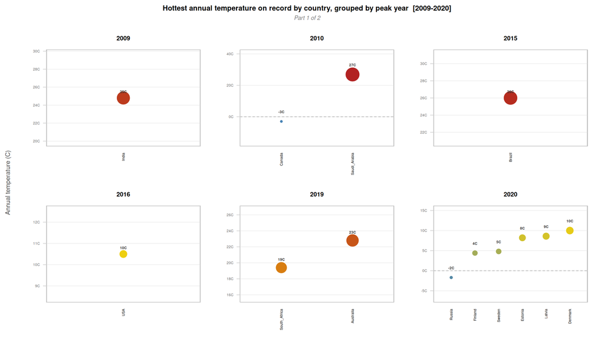

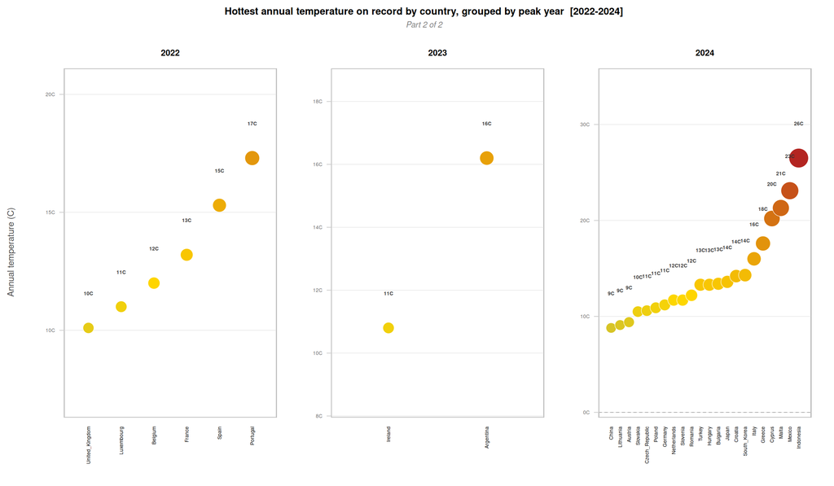

```r
plot_bubble_panel(
  data     = extreme_years,
  temp_col = "Hottest",
  year_col = "Year_Hot",
  title    = "Hottest annual temperature on record by country, grouped by peak year",
  ramp     = c("steelblue", "gold", "firebrick"),
  unit     = "C"
)
```

## 10.4 Años más fríos

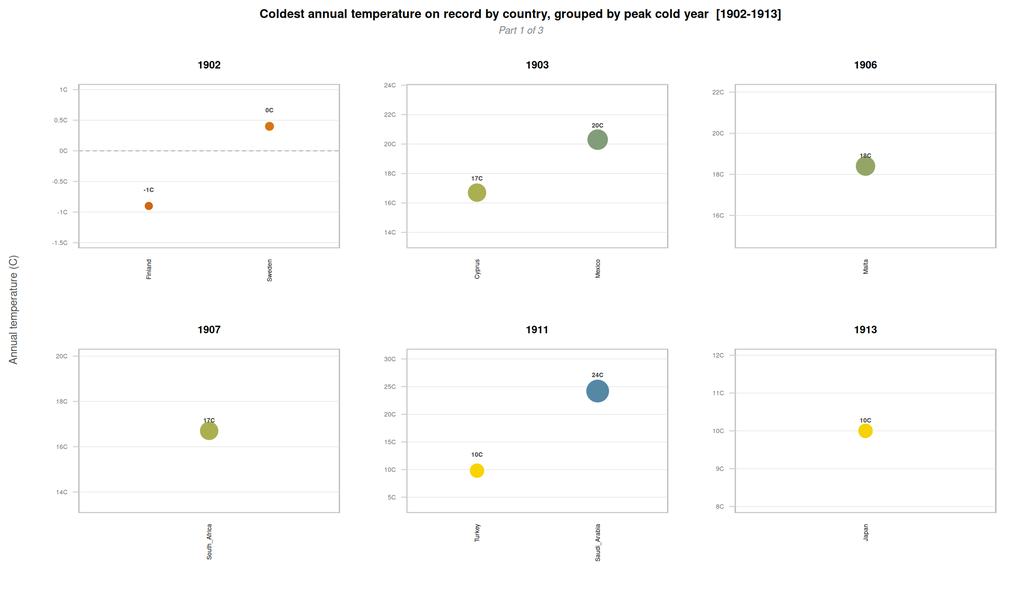

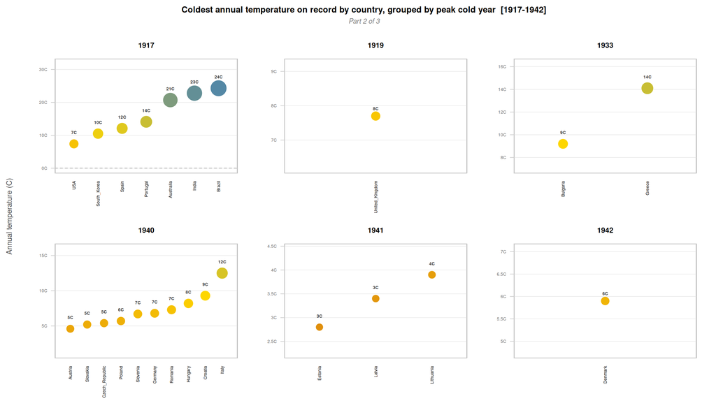

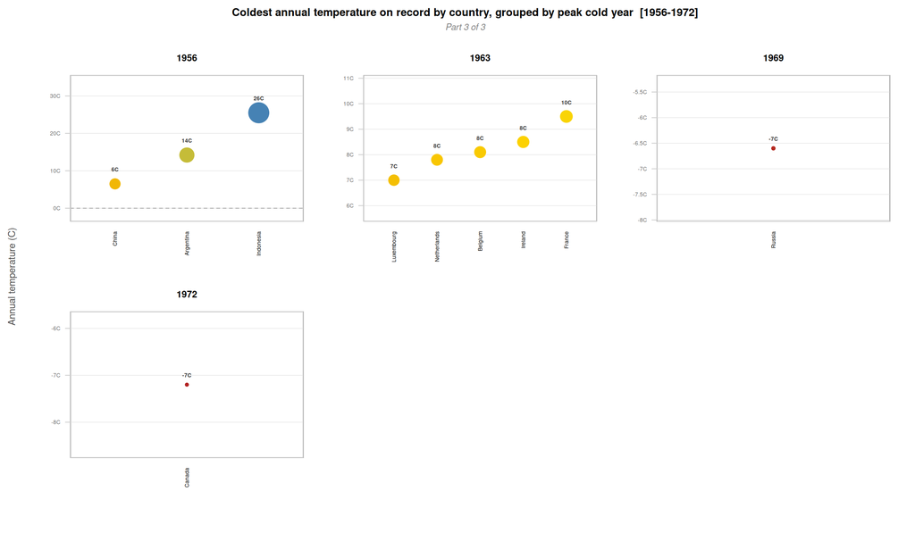

```r
plot_bubble_panel(
  data     = extreme_years,
  temp_col = "Coldest",
  year_col = "Year_Cold",
  title    = "Coldest annual temperature on record by country, grouped by peak cold year",
  ramp     = c("firebrick", "gold", "steelblue"),
  unit     = "C"
)
```

# 11 Sección 8: Temperatura Estacional — 7 Países

Comparamos la temperatura media por estación para países de diferentes zonas climáticas.

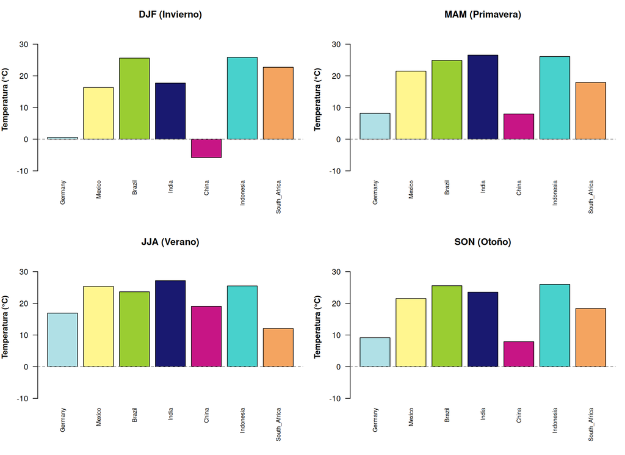

Temperatura media estacional para 7 países de distintas zonas climáticas

```r
selected <- c("Germany", "Mexico", "Brazil", "India",
              "China", "Indonesia", "South_Africa")
seasons  <- c("DJF", "MAM", "JJA", "SON")
season_labels <- c("DJF (Invierno)", "MAM (Primavera)",
                   "JJA (Verano)",   "SON (Otoño)")
country_colors <- c("#B0E0E6", "#FFF68F", "#9ACD32", "#191970",
                    "#C71585", "#48D1CC", "#F4A460")

par(mfrow = c(2, 2), mar = c(6, 4, 3, 1))

for (i in seq_along(seasons)) {
  s <- seasons[i]
  seasonal_means <- sapply(selected, function(country) {
    key <- paste0(country, "_tmp")
    if (key %in% names(climate_data)) {
      mean(climate_data[[key]][[s]], na.rm = TRUE)
    } else NA
  })

  barplot(seasonal_means,
          names.arg = selected,
          col       = country_colors,
          main      = season_labels[i],
          ylab      = "Temperatura (°C)",
          ylim      = c(-10, 35),
          las       = 2,
          cex.names = 0.75,
          font.lab  = 2)

  abline(h = 0, col = "gray50", lty = 2)
}
```

```r
par(mfrow = c(1, 1))
```

> **Nota:** La estacionalidad de DJF e JJA está **invertida** entre hemisferios: cuando es invierno en Alemania (DJF), es verano en Brasil y Sudáfrica.